# EstimationBiomass

Sonisa Sharma

August 8, 2019

## Load the packages

*The aim of this script is to create a database that includes data from Alfalfa, Bermuda grass, Brassica, Tall fescue, and the wheat. There are two sets of data 1) the historical data from where we will find the best model and then implemented in the 2) new datasets, use the models to estimate the accuracy*

## Load the Forage tower data and physical data and then merge those files and use best model for each variety to estimate biomass in new incoming data. For finding the best model, we need to use historical data and figure out which one is better

# Part 1: Field data

*The overall explore is to explore the data related to foarge tower especially the canopy height, biomass from clipping and the biomass from the tower.In this section, we will get only the harvest date, species, cultivar,sample dry weight in g, quad size in m2, clipped foarge yield, canopy height, inflorescence height, and average biomass from the cart.New datasets will include only these datasets.*

## Unmerge the file based on physical and sensor data

## Now merge both the data based on sensor date and physicaldata based on unique identifiers sensor.date and id

*For a given predictor (p), multicollinearity can assessed by computing a score called the variance inflation factor (or VIF), which measures how much the variance of a regression coefficient is inflated due to multicollinearity in the model. In this script, we will figure out which models is better in estimating biomass and then used the best model in the new set of data*

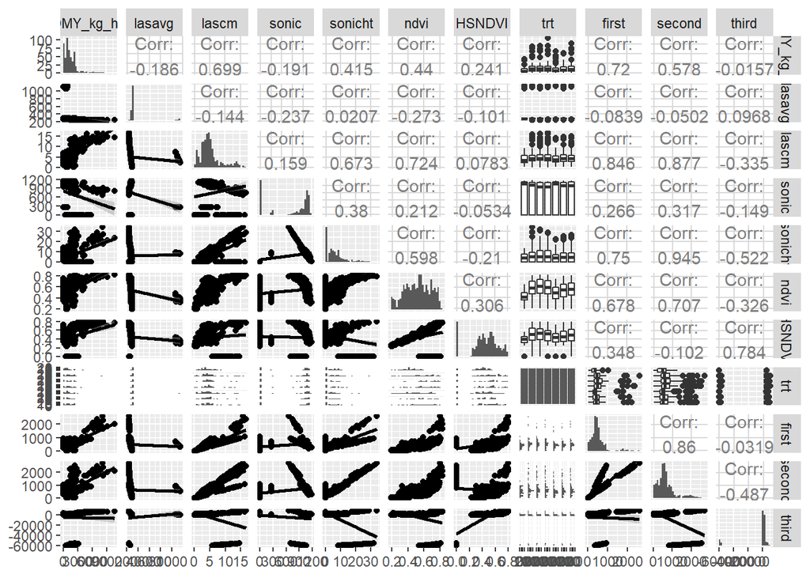

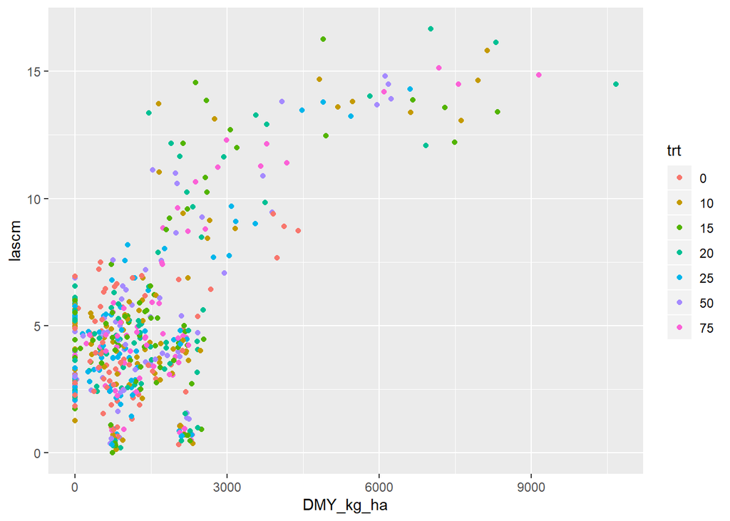

# Fit and interpret the model

```
##
## Call:
## lm(formula = .outcome ~ ., data = dat)
##
## Residuals:
##     Min      1Q  Median      3Q     Max
## -417.12  -54.68  -13.39   45.74  518.74
##
## Coefficients:
##               Estimate Std. Error t value Pr(>|t|)
## (Intercept) -5.401e+04  3.611e+03 -14.959  < 2e-16 ***
## sensor.date  3.159e+00  2.117e-01  14.927  < 2e-16 ***
## DMY_kg_ha    8.167e-02  5.627e-03  14.516  < 2e-16 ***
## lasavg       2.191e-01  3.580e-02   6.120 2.15e-09 ***
## lascm        3.896e+01  3.707e+00  10.511  < 2e-16 ***
## sonicht      2.146e+01  1.366e+00  15.713  < 2e-16 ***
## ndvi         2.114e+02  6.305e+01   3.354  0.00087 ***
## ---
## Signif. codes:  0 '***' 0.001 '**' 0.01 '*' 0.05 '.' 0.1 ' ' 1
##
## Residual standard error: 130.7 on 421 degrees of freedom
## Multiple R-squared:  0.882,  Adjusted R-squared:  0.8804
## F-statistic: 524.7 on 6 and 421 DF,  p-value: < 2.2e-16
```

```
##         2         3         4         5         9
##  67.72963  90.20634 115.26621 291.71444  40.74814
```

```
##         2         3         4         5         9        11        18
##  67.72963  90.20634 115.26621 291.71444  40.74814   4.39863  92.76156
##        30        31        33
## 527.49546 733.69780 964.29644
```

```
##       RMSE        R2
## 1 140.9382 0.8907229
```

```
## [1] 1
```

```
## [1] 1
```

[figure not shown]

# Lets used different machine learning method such as random forest, ANN method